# Self-Driving Car Engineer Nanodegree

## Test Images

Build your pipeline to work on the images in the directory "test_images"  
**You should make sure your pipeline works well on these images before you try the videos.**

```python
imglst = os.listdir("test_images/")
print(imglst)
```

```
['solidWhiteCurve.jpg', 'solidYellowCurve2.jpg', 'solidWhiteRight.jpg', 'whiteCarLaneSwitch.jpg', 'solidYellowLeft.jpg', 'solidYellowCurve.jpg']
```

## Building functions for lane finding

```python
# TODO: Build your pipeline that will draw lane lines on the test_images
# then save them to the test_images_output directory.

def apply_mask(imgin):
    """
    This function applies the inclusion exclusion mask to removes the areas which
    are outside of region of interest so the noise effect is minimimum"""
    mask_idx = np.array([[(430/960.0,320/540.0),(540/960.0,320/540.0),(920/960.0,538/540.0),(100/960.0,538/540.0)]],dtype=np.float32)
    mask_idx = np.multiply(np.array([imgin.shape[1],imgin.shape[0]]),mask_idx)

    #Removes all noise outside center region
    imgout = region_of_interest(imgin,np.asarray(mask_idx,dtype=np.int32))

    mask_idx = np.array([[(430/960.0,400/540.0),(540/960.0,400/540.0),(760/960.0,538/540.0),(300/960.0,538/540.0)]],dtype=np.float32)
    mask_idx = np.multiply(np.array([imgin.shape[1],imgin.shape[0]]),mask_idx)

    #Removes all noise under center region
    imgout = region_of_interest(imgout,np.asarray(mask_idx,dtype=np.int32),False)

    return imgout

def find_white_markings(imgin):
    """
    This function finds the white marking on the road. The same function
    can work for yellow lines but results are not very reliable and get
    affected by shadows and high illumination
    """
    img_channel =  np.squeeze(np.maximum(np.maximum(imgin[:,:,1],imgin[:,:,2]),imgin[:,:,0]))
    img_channel_smoothened = gaussian_blur(img_channel,9)
    img_canny = canny(img_channel_smoothened,60,80)

    #apply inclusion/exclusion mask
    img_binarized = apply_mask(img_canny)

    #get hough lines as 1-0
    lines,img_hgh_lines = hough_lines(img_binarized, 1, 1*np.pi/180,4,5, 10)

    #fill the holes made by drawing the hough lines to create uniform strips
    kernel = np.ones((7,7),np.uint8)
    img_binarized = cv2.morphologyEx(np.squeeze(img_hgh_lines), cv2.MORPH_CLOSE, kernel)

#    return img_normalize
    return img_binarized

def find_yellow_markings(imgin):
    """
    This function finds the yellow marking on the road. It uses HSV
    transform to generate the hue,saturation,value component of the image
    Then it uses cv2.inRange to find the relevant yellow pixels in the image
    """
    img_hsv = hsvscale(imgin)

    #bounds for yellow color
    lower_yellow = np.array([15,65,65])
    upper_yellow = np.array([35,255,255])

    # Threshold the HSV image to get only yellow colors
    yellow_region = cv2.inRange(img_hsv, lower_yellow, upper_yellow)

    #apply inclusion/exclusion mask
    mask = apply_mask(yellow_region)
    #fill the holes to create uniform strips
    kernel = np.ones((5,5),np.uint8)
    mask_close = cv2.morphologyEx(mask, cv2.MORPH_CLOSE, kernel)

    return mask_close

def get_skel(imgin):
    """
    This function implements the morphological operaiton of obtaining
    skeleton of the binary image. This function is to good center
    relevant points so line fitting is easier
    """
    element = np.ones((3,3),np.uint8)#v2.getStructuringElement(cv2.MORPH_CROSS,(3,3))
    done = False
    img = imgin
    size = np.size(img)
    skel = np.zeros(img.shape,np.uint8)

    while( not done):
        eroded = cv2.erode(img,element)
        temp = cv2.dilate(eroded,element)
        temp = cv2.subtract(img,temp)
        skel = cv2.bitwise_or(skel,temp)
        img = eroded.copy()

        zeros = size - cv2.countNonZero(img)
        if zeros==size:
            done = True

    return skel

def draw_poly_fit(imgin,poly_fitted):
    """
    This functions draws the fitted lines on the maskimg.
    It evaluates the polynomial points and then check for
    their ranges and then draw.
    """
    xc = np.array(range(imgin.shape[0]))
    aaa = int(320.0 *imgin.shape[0]/540.0);

    xc = np.array(range(imgin.shape[0]-aaa))
    xc = xc+aaa;

    #load polynomial
    p = np.poly1d(poly_fitted)

    #evaluate
    yc = p(xc)

    yc = np.asarray(yc,dtype=np.int32)

    #check bounds
    yc1 = yc[yc>=0]
    yc2 = yc1[yc1<imgin.shape[1]]
    xc1 = xc[yc>=0]
    xc2 = xc1[yc1<imgin.shape[1]]

    mask_img = np.array(imgin)*0;
    for ixx in np.array(range(yc2.shape[0]-1)):
        cv2.line(mask_img, (yc2[ixx],xc2[ixx]), (yc2[ixx+1], xc2[ixx+1]), [255,0,0], 5)

    return mask_img


def find_lane_line(imgin,img_binarized,prev_frame_fit,isleft = True):
    """
    This function finds the points in the mask images
    and tries to fit a first order polynomial(line) and on
    failing for a good fit tries to find the second order
    polynomial and if unsuccessful default to prev frame
    """

    a,b = np.nonzero(img_binarized);
    yindx = int(img_binarized.shape[1]*0.52);

    if isleft == False:
        a = a[b>yindx]
        b = b[b>yindx]
    else:
        a = a[b<=yindx]
        b = b[b<=yindx]

    # try first order polynomial if it fit
    fit_poly = ransac_polyfit(a, b, order=1, n=20, k=300, t=8, d=60, f=0.6)
    if len(fit_poly) == 0:
        # try second order_polynomial
        fit_poly = ransac_polyfit(a, b, order=2, n=20, k=500, t=15, d=60, f=0.7)
    #if fails to find in current frame, use from nearby frames
    if(len(fit_poly) == 0):
        fit_poly = prev_frame_fit;

    drawn_lane_line = draw_poly_fit(imgin,fit_poly)

    return drawn_lane_line,fit_poly
```

## Building the pipeline using functions above

```python
"""
    This function has the entire pipeline for the project.
    It first find the lane markings using the edge/color.
    Then it find those as skeltons and fits polynomial functions
    using RANSAC. It then draws those polynomials on the image
"""
def pipeline(imgin):

    #find the yellow and white marking
    img_white = find_white_markings(imgin)
    img_yellow = find_yellow_markings(imgin)

    #return(np.concatenate((img_white[:,:,np.newaxis],img_white[:,:,np.newaxis],img_white[:,:,np.newaxis]),axis=2))

    #add up the results
    lanes_binarized = np.maximum(img_yellow,img_white)

    #create a buffer in between lines
    yindx = int(lanes_binarized.shape[1]*0.52);
    lanes_binarized[:,yindx-20:yindx+2] = 0;

    #generate single width line
    skel_lanes_binarized = get_skel(lanes_binarized)

    #fetch temporal poly_fit_coeff and find lanes by polyfitting
    global prev_l
    global prev_r
    left_lane_mask,prev_l = find_lane_line(imgin,skel_lanes_binarized,prev_l,isleft = True)
    right_lane_mask,prev_r = find_lane_line(imgin,skel_lanes_binarized,prev_r,isleft = False)

    lanes_mask = np.maximum(left_lane_mask,right_lane_mask)

    #Adding the lane mask to original images
    imgout = (weighted_img(lanes_mask,imgin))

    #return(np.concatenate((img_white[:,:,np.newaxis],img_white[:,:,np.newaxis],img_white[:,:,np.newaxis]),axis=2))
    return imgout
```

## Testing on the input test Images

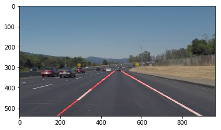

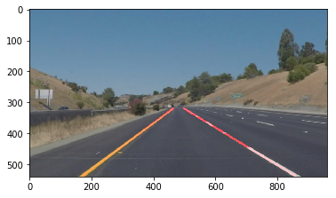

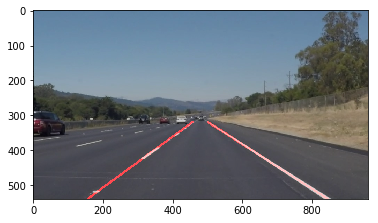

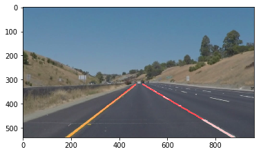

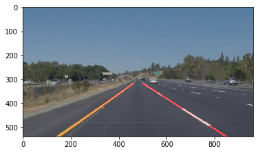

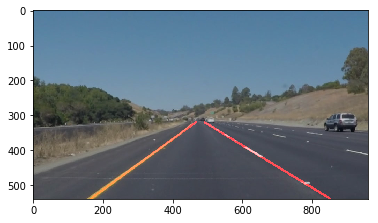

```python
prev_l = [];
prev_r = [];
for idx in range(len(imglst)):
    img = mpimg.imread("test_images/"+imglst[idx])

    l = pipeline(img)

    plt.figure(idx)
    plt.imshow(l)
```

## Test on Videos

You know what's cooler than drawing lanes over images? Drawing lanes over video!

We can test our solution on two provided videos:

`solidWhiteRight.mp4`

`solidYellowLeft.mp4`

**Note: if you get an import error when you run the next cell, try changing your kernel (select the Kernel menu above --> Change Kernel). Still have problems? Try relaunching Jupyter Notebook from the terminal prompt. Also, consult the forums for more troubleshooting tips.**

**If you get an error that looks like this:**

```
NeedDownloadError: Need ffmpeg exe.
You can download it by calling:
imageio.plugins.ffmpeg.download()
```

**Follow the instructions in the error message and check out [this forum post](https://discussions.udacity.com/t/project-error-of-test-on-videos/274082) for more troubleshooting tips across operating systems.**

```python
# Import everything needed to edit/save/watch video clips
from moviepy.editor import VideoFileClip
from IPython.display import HTML
```

```python
def process_image(image):
    # NOTE: The output you return should be a color image (3 channel) for processing video below
    # TODO: put your pipeline here,
    # you should return the final output (image where lines are drawn on lanes)
    b = np.array(solve(image))
    return b
```

Let's try the one with the solid white lane on the right first ...

```python
if not os.path.exists('test_videos_output'):
    os.mkdir('test_videos_output')
white_output = 'test_videos_output/solidWhiteRight.mp4'
prev_l = [];
prev_r = [];

## To speed up the testing process you may want to try your pipeline on a shorter subclip of the video
## To do so add .subclip(start_second,end_second) to the end of the line below
## Where start_second and end_second are integer values representing the start and end of the subclip
## You may also uncomment the following line for a subclip of the first 5 seconds
##clip1 = VideoFileClip("test_videos/solidWhiteRight.mp4").subclip(0,5)
clip1 = VideoFileClip("test_videos/solidWhiteRight.mp4")
white_clip = clip1.fl_image(pipeline) #NOTE: this function expects color images!!
%time white_clip.write_videofile(white_output, audio=False)
```

```
[MoviePy] >>>> Building video test_videos_output/solidWhiteRight.mp4
[MoviePy] Writing video test_videos_output/solidWhiteRight.mp4
```

```
[MoviePy] Done.
[MoviePy] >>>> Video ready: test_videos_output/solidWhiteRight.mp4

CPU times: user 6min 2s, sys: 589 ms, total: 6min 3s
Wall time: 6min 5s
```

Play the video inline, or if you prefer find the video in your filesystem (should be in the same directory) and play it in your video player of choice.

```python
HTML("""
<video width="960" height="540" controls>
  <source src="{0}">
</video>
""".format(white_output))
```

[video not shown]

## Improve the draw_lines() function

**At this point, if you were successful with making the pipeline and tuning parameters, you probably have the Hough line segments drawn onto the road, but what about identifying the full extent of the lane and marking it clearly as in the example video (P1_example.mp4)? Think about defining a line to run the full length of the visible lane based on the line segments you identified with the Hough Transform. As mentioned previously, try to average and/or extrapolate the line segments you've detected to map out the full extent of the lane lines. You can see an example of the result you're going for in the video "P1_example.mp4".**

**Go back and modify your draw_lines function accordingly and try re-running your pipeline. The new output should draw a single, solid line over the left lane line and a single, solid line over the right lane line. The lines should start from the bottom of the image and extend out to the top of the region of interest.**

Now for the one with the solid yellow lane on the left. This one's more tricky!

```python
if not os.path.exists('test_videos_output'):
    os.mkdir('test_videos_output')
yellow_output = 'test_videos_output/solidYellowLeft.mp4'
prev_l = [];
prev_r = [];
## To speed up the testing process you may want to try your pipeline on a shorter subclip of the video
## To do so add .subclip(start_second,end_second) to the end of the line below
## Where start_second and end_second are integer values representing the start and end of the subclip
## You may also uncomment the following line for a subclip of the first 5 seconds
##clip2 = VideoFileClip('test_videos/solidYellowLeft.mp4').subclip(0,5)
clip2 = VideoFileClip('test_videos/solidYellowLeft.mp4')
yellow_clip = clip2.fl_image(pipeline)
%time yellow_clip.write_videofile(yellow_output, audio=False)
```

```
[MoviePy] >>>> Building video test_videos_output/solidYellowLeft.mp4
[MoviePy] Writing video test_videos_output/solidYellowLeft.mp4
```

```
[MoviePy] Done.
[MoviePy] >>>> Video ready: test_videos_output/solidYellowLeft.mp4

CPU times: user 19min 12s, sys: 2.08 s, total: 19min 14s
Wall time: 19min 21s
```

```python
HTML("""
<video width="960" height="540" controls>
  <source src="{0}">
</video>
""".format(yellow_output))
```

[video not shown]

## Writeup and Submission

If you're satisfied with your video outputs, it's time to make the report writeup in a pdf or markdown file. Once you have this Ipython notebook ready along with the writeup, it's time to submit for review! Here is a [link](https://github.com/udacity/CarND-LaneLines-P1/blob/master/writeup_template.md) to the writeup template file.

## Optional Challenge

Try your lane finding pipeline on the video below. Does it still work? Can you figure out a way to make it more robust? If you're up for the challenge, modify your pipeline so it works with this video and submit it along with the rest of your project!

```python
if not os.path.exists('test_videos_output'):
    os.mkdir('test_videos_output')
challenge_output = 'test_videos_output/challenge.mp4'
prev_l = [];
prev_r = [];
## To speed up the testing process you may want to try your pipeline on a shorter subclip of the video
## To do so add .subclip(start_second,end_second) to the end of the line below
## Where start_second and end_second are integer values representing the start and end of the subclipgrayscale
## You may also uncomment the following line for a subclip of the first 5 seconds
##clip3 = VideoFileClip('test_videos/challenge.mp4').subclip(0,5)
clip3 = VideoFileClip('test_videos/challenge.mp4')
challenge_clip = clip3.fl_image(pipeline)
%time challenge_clip.write_videofile(challenge_output, audio=False)
```

```
[MoviePy] >>>> Building video test_videos_output/challenge.mp4
[MoviePy] Writing video test_videos_output/challenge.mp4
```

```
[MoviePy] Done.
[MoviePy] >>>> Video ready: test_videos_output/challenge.mp4

CPU times: user 29min 44s, sys: 2.23 s, total: 29min 46s
Wall time: 29min 56s
```

```python
HTML("""
<video width="960" height="540" controls>
  <source src="{0}">
</video>
""".format(challenge_output))
```

[video not shown]